# Project: *Are Horror Movies that Bad?!*

- Introduction
- Data Wrangling
- Exploratory Data Analysis
- Conclusions

## Introduction

> One of my favorite kind of movies is, as you might have guessed it already, horror movies. I’ve been a fan since my childhood and the only thing that has changes is that now I can sleep alone after seeing one.

> I must say that despite being a fan, I have to agree with the idea that the horror movies are not the best ones out there. But I am also aware that since, as a fan, I’ve watched many, it’s quite natural that I’ve seen a considerable chunk of bad ones.

> So, how bad are the horror movies compared to the rest?

> In the analysis of the IMDB data I will try to find some answers to these questions:
> > 1. How are horror movies compared to the other genres in terms of rating and financial numbers?
> > 2. Are any horror sub-genres better that others?
> > 3. Are big names in the industry (actors and directors) sharing their talents with the horror genre?

```python
#import the packages I'll be using for the analysis.

import pandas as pd
import numpy as np
% matplotlib inline
import matplotlib.pyplot as plt
```

## Data Wrangling

> For the data wrangling stage, my plan is:

> > Load the original data and check the overall structure of the dataset;  
> > Clean the data: drop unnecessary columns, drop unnecessary rows (including NaN or duplicates), reformat the data and create new features, check for other anomalies and deal with those.

### General Properties

```python
# The data can be loaded for analysis either via the first command or the second, \
# with the risk that loading from the web you might work on an updated dataset and the results will differ.
# Don't execute both! add or remove the "#" in front of the code - remove to execute.

#1. From the current environment - data I used.

origin_df=pd.read_csv('tmdb-movies.csv')

#2. From the web.

#origin_df=pd.read_csv('https://d17h27t6h515a5.cloudfront.net/topher/2017/October/59dd1c4c_tmdb-movies/tmdb-movies.csv')
```

> Let's check the header and a few rows of data, the dataset's structure and the main statistics to get a first glimpse on what data is available, what's it's quality and figure out what we need to do in order to prepare it for analysis.

```python
origin_df.head(2)
```

|  | id | imdb_id | popularity | budget | revenue | original_title | cast | homepage | director | tagline | ... | overview | runtime | genres | production_companies | release_date | vote_count | vote_average | release_year | budget_adj | revenue_adj |
| --- | --- | --- | --- | --- | --- | --- | --- | --- | --- | --- | --- | --- | --- | --- | --- | --- | --- | --- | --- | --- | --- |
| 0 | 135397 | tt0369610 | 32.985763 | 150000000 | 1513528810 | Jurassic World | Chris Pratt\|Bryce Dallas Howard\|Irrfan Khan\|Vi... | http://www.jurassicworld.com/ | Colin Trevorrow | The park is open. | ... | Twenty-two years after the events of Jurassic ... | 124 | Action\|Adventure\|Science Fiction\|Thriller | Universal Studios\|Amblin Entertainment\|Legenda... | 6/9/2015 | 5562 | 6.5 | 2015 | 137999939.3 | 1.392446e+09 |
| 1 | 76341 | tt1392190 | 28.419936 | 150000000 | 378436354 | Mad Max: Fury Road | Tom Hardy\|Charlize Theron\|Hugh Keays-Byrne\|Nic... | http://www.madmaxmovie.com/ | George Miller | What a Lovely Day. | ... | An apocalyptic story set in the furthest reach... | 120 | Action\|Adventure\|Science Fiction\|Thriller | Village Roadshow Pictures\|Kennedy Miller Produ... | 5/13/2015 | 6185 | 7.1 | 2015 | 137999939.3 | 3.481613e+08 |

2 rows × 21 columns

```python
origin_df.info()
```

```
<class 'pandas.core.frame.DataFrame'>
RangeIndex: 10866 entries, 0 to 10865
Data columns (total 21 columns):
id                      10866 non-null int64
imdb_id                 10856 non-null object
popularity              10866 non-null float64
budget                  10866 non-null int64
revenue                 10866 non-null int64
original_title          10866 non-null object
cast                    10790 non-null object
homepage                2936 non-null object
director                10822 non-null object
tagline                 8042 non-null object
keywords                9373 non-null object
overview                10862 non-null object
runtime                 10866 non-null int64
genres                  10843 non-null object
production_companies    9836 non-null object
release_date            10866 non-null object
vote_count              10866 non-null int64
vote_average            10866 non-null float64
release_year            10866 non-null int64
budget_adj              10866 non-null float64
revenue_adj             10866 non-null float64
dtypes: float64(4), int64(6), object(11)
memory usage: 1.7+ MB
```

```python
origin_df.describe()
```

|  | id | popularity | budget | revenue | runtime | vote_count | vote_average | release_year | budget_adj | revenue_adj |
| --- | --- | --- | --- | --- | --- | --- | --- | --- | --- | --- |
| count | 10866.000000 | 10866.000000 | 1.086600e+04 | 1.086600e+04 | 10866.000000 | 10866.000000 | 10866.000000 | 10866.000000 | 1.086600e+04 | 1.086600e+04 |
| mean | 66064.177434 | 0.646441 | 1.462570e+07 | 3.982332e+07 | 102.070863 | 217.389748 | 5.974922 | 2001.322658 | 1.755104e+07 | 5.136436e+07 |
| std | 92130.136561 | 1.000185 | 3.091321e+07 | 1.170035e+08 | 31.381405 | 575.619058 | 0.935142 | 12.812941 | 3.430616e+07 | 1.446325e+08 |
| min | 5.000000 | 0.000065 | 0.000000e+00 | 0.000000e+00 | 0.000000 | 10.000000 | 1.500000 | 1960.000000 | 0.000000e+00 | 0.000000e+00 |
| 25% | 10596.250000 | 0.207583 | 0.000000e+00 | 0.000000e+00 | 90.000000 | 17.000000 | 5.400000 | 1995.000000 | 0.000000e+00 | 0.000000e+00 |
| 50% | 20669.000000 | 0.383856 | 0.000000e+00 | 0.000000e+00 | 99.000000 | 38.000000 | 6.000000 | 2006.000000 | 0.000000e+00 | 0.000000e+00 |
| 75% | 75610.000000 | 0.713817 | 1.500000e+07 | 2.400000e+07 | 111.000000 | 145.750000 | 6.600000 | 2011.000000 | 2.085325e+07 | 3.369710e+07 |
| max | 417859.000000 | 32.985763 | 4.250000e+08 | 2.781506e+09 | 900.000000 | 9767.000000 | 9.200000 | 2015.000000 | 4.250000e+08 | 2.827124e+09 |

### First few points:

So we have information regarding almost 11k movies, from 1960 until 2015, including title, plot details, director, cast, ratings and financial data.

> **Structure** - the dataset has 10866 records with 21 columns; all columns are properly named and formatted;  
> **Completeness** - There are (obvious) missing values in a few columns: imdb_id homepage, director, tagline, keywords, overview, genres, production_companies;  
> **Datatypes** - there is an inappropriate data type: release_date should be datetime not string (object);  
> **Anomalies**- the financial data (revenue and budget) seem odd as half of them (see the 50% percentile) are 0. These will need a closer look.

## Data Cleaning

> As mentioned in the beginning, the steps are:
> > - drop unnecessary columns;
> > - reformat the data;
> > - drop unnecessary rows (including NaN or duplicates);
> > - create new features;
> > - check for other anomalies and deal with those.

### Data Cleaning: 1. drop columns we do not need

> **'imdb_id'** - there are missing values and we do not need to join with some other IMDB database; we will use the id, which has no missing values if we need to single out a specific line.  
> **'popularity'** - this represents the frequency of accessing that movie in the current week - so we would actually need a list of popularity /week if we were to extract some knowledge. The popularity of the who-knows-which week of the data extraction is not really relevant.  
> **'budget'** and **'revenue'** - we also have the same measures adjusted for inflation which will help us compare apples with apples, so we don't need the original measures.  
> **'homepage'**- we won't be surfing the internet, so don't need for them.  
> **'tagline'**- besides missing values, we already have keywords and overview, so it should be enough to extract some pertinent "tagging" of the movies. Usually taglines tend to be marketing catchphrases, not really informative statements.  
> **'production_companies'** - I won't be using these because nowadays there's HBO, Netflix and Amazon :).  
> **'release_date'** - we already have the release_year and since we have a considerable time-span (1960-2015) we won't need date level of granularity.

```python
clean_df1 = origin_df.drop(['imdb_id', 'popularity', 'budget', 'revenue',  'homepage', 'tagline',\
                            'production_companies', 'release_date'], axis=1)
```

### Data Cleaning: 2. Adjusting values and formats

> - I will convert the budget and revenues into millions, because, if you look at the descriptive statistics the measures are shown with error (which is very hard to read). Regarding the many 0s in the dataset (for the financials) we will visit the topic later, after we finish the easy tasks.

```python
#divide the budget and revenue by 1M and round up to 4 digits.
clean_df1['budget_adj']=(clean_df1['budget_adj']/1000000).round(4)
clean_df1['revenue_adj']=(clean_df1['revenue_adj']/1000000).round(4)
```

```python
clean_df1.describe()
```

|  | id | runtime | vote_count | vote_average | release_year | budget_adj | revenue_adj |
| --- | --- | --- | --- | --- | --- | --- | --- |
| count | 10866.000000 | 10866.000000 | 10866.000000 | 10866.000000 | 10866.000000 | 10866.000000 | 10866.000000 |
| mean | 66064.177434 | 102.070863 | 217.389748 | 5.974922 | 2001.322658 | 17.551039 | 51.364364 |
| std | 92130.136561 | 31.381405 | 575.619058 | 0.935142 | 12.812941 | 34.306155 | 144.632485 |
| min | 5.000000 | 0.000000 | 10.000000 | 1.500000 | 1960.000000 | 0.000000 | 0.000000 |
| 25% | 10596.250000 | 90.000000 | 17.000000 | 5.400000 | 1995.000000 | 0.000000 | 0.000000 |
| 50% | 20669.000000 | 99.000000 | 38.000000 | 6.000000 | 2006.000000 | 0.000000 | 0.000000 |
| 75% | 75610.000000 | 111.000000 | 145.750000 | 6.600000 | 2011.000000 | 20.853300 | 33.697075 |
| max | 417859.000000 | 900.000000 | 9767.000000 | 9.200000 | 2015.000000 | 425.000000 | 2827.123800 |

> - The Budget and revenue are readable now. Let's move on.

### Data Cleaning: 3. Dropping rows - Missing data, Duplicates, Irrelevant data

> I'll start with the latter -**Irrelevant data**: The central limit theorem rule of thumb sais if the data is normally distributed, you need a sample of size > 30 so your results (average for instance) are relevant for the population.  
> Many of the mean average ratings in the dataset are the result of less than 30 votes - if you look at the 25th percentile you will see it's 17 votes and the 50th is 38. Moreover, we do not know if the rating scores in the population are normally distributed (if not, than 30 counts would be insufficient).  
> Based on the IMDB statements, they are actually using a weighted average algorithm that is secret so we should probably trust the relevance of the rating even for the ones with less than 30 votes. However... let's compare the average of the movies with less than 30 votes vs the overall sample, and see if the difference is significant.

```python
# compute the average of vote average for movies with bellow and over 30 votes.

avg_rate_30 = clean_df1['vote_average'][clean_df1['vote_count']<30].mean()
avg_rate_all = clean_df1['vote_average'].mean()
print('Average rating of movies with less than 30 votes: ', avg_rate_30,'\nAverage rating of all movies: ',avg_rate_all)
```

```
Average rating of movies with less than 30 votes:  5.74400677679
Average rating of all movies:  5.97492177434
```

> - It looks like the averages are not that different after all, so the IMDB must be doing it right. I'll trust their data. The average rating of the movies with less votes is smaller, but maybe that is because the movies are too bad to get enough visibility and voters. We'll never know.
> - Next, I am interested in movies, not shorts or series, so:
>   > - I would remove all movies with a runtime less than 80min
>   > - for sure I will remove all than run for more than 240min (4h)

But, for safety let's look at the volume and distribution of the movies <80min and also check what is going on between 160m (which seems to be a fair cut-off point) and 240min.

```python
# count the movies with duration bellow 80min and over 240min votes.

mov80=clean_df1['runtime'][clean_df1['runtime']<80].count()
mov240=clean_df1['runtime'][clean_df1['runtime']>240].count()
print('Movies less than 80min long:', mov80,'\nMovies more than 240min long:', mov240)
```

```
Movies less than 80min long: 748
Movies more than 240min long: 42
```

```
Text(0.5,0,'minutes')
```

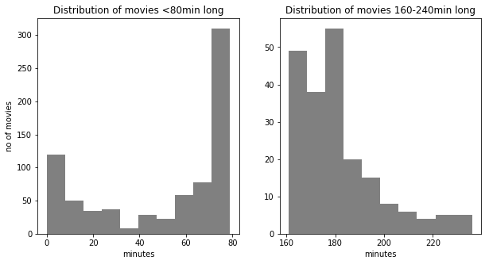

```python
# create 2 subplots for movies bellow 80min and between 160-240min

f_len = plt.figure(figsize=(10,5))
ax81 = f_len.add_subplot(121,title='Distribution of movies <80min long')
ax82 = f_len.add_subplot(122,title='Distribution of movies 160-240min long')

# add the histograms for for movies bellow 80min and between 160-240min

ax81.hist(clean_df1['runtime'][clean_df1['runtime']<80],color=['grey'])
ax82.hist(clean_df1['runtime'][(clean_df1['runtime']>160)&(clean_df1['runtime']<240)],color=['grey'])

# set the axis labels

ax81.set_ylabel('no of movies')
ax81.set_xlabel('minutes')
ax82.set_xlabel('minutes')
```

> - There are 748 movies shorter than 80 minutes, out of which there are some 300+ movies with a duration between 70 and 80 min, but considering the size of the dataset I will leave them out (I don't trust a movie that's that short).
> - Also, there are 42 movies longer than 240 minutes, which I'll exclude. Also, I will leave out all that are above 200min, as those look more like outliers.
> - I will duplicate the dataset so that, in case I change my mind on the cleaning, to have less steps that need to be redone.

```python
# copy the latest cleaned df version
clean_df2 = clean_df1.copy(deep=True)

# filter out the durations that are not appropriate.
clean_df2 = clean_df2[(clean_df2['runtime']>=80) & (clean_df2['runtime']<=200)]
```

> - Next let's **drop the NaN**. I will ignore the keywords column in this step, as I will be using it in conjunction with the overview, so having NaN won't be an issue.

```python
# remove the NA from the selected columns
clean_df2.dropna(subset=['id','original_title', 'cast', 'director','overview', 'runtime', 'genres', \
                         'vote_count', 'vote_average', 'release_year', 'budget_adj','revenue_adj'], inplace = True)
```

> - Finally, we need to check for **duplicates** and remove them.

```python
# show the number of duplicates.
clean_df2.duplicated()[clean_df1.duplicated()==True].count()
```

```
1
```

```python
#remove the duplicates
clean_df2.drop_duplicates(inplace=True)
```

```python
# show the number of duplicates.
clean_df2.duplicated()[clean_df1.duplicated()==True].count()
```

```
0
```

> - The duplicates were actually one duplicate and it was removed.

Let's proceed with adding some extra columns to help us with our deep dive into the horror realm.

### Data Cleaning: 4. Adding columns

**Genre and sub-genre columns**

As I was saying, I am curious about how the horror movies are performing vs. the rest of the genres. So I'll need to be able to make this distinction.

> - First, let's create a column that flags each line as horror or not, and we'll do that by searching for 'horror' in the 'genres' column.

```python
# add a new column horror and populate it with true or false > True when the genres column contains horror
clean_df2['horror']=clean_df2['genres'].str.match(pat='horror', case=False)
```

> - I also want to check, within the horror genre, which theme perform best. I chose **zombies**, **vampires**, **devil_ghost** (devil, demons, ghosts, possessions and spirits), **psycho** (...killers), and the rest I put them in **others**; I'll be searching for the keywords in the overview and keywords columns. Sure, the quality of this assessment is resting on the completeness and accuracy of overview and keywords, but that's the best we can do with the data we have.

```python
# add subgenres columns and populate them with true or false > True when either the overview \
# or keywords columns contain the specified words.

clean_df2['zombies']=clean_df2['overview'].str.contains('zombie', case=False)|\
clean_df2['keywords'].str.contains('zombie', case=False)

clean_df2['vampires']=clean_df2['overview'].str.contains('vampire|nosferatu', case=False) |\
clean_df2['keywords'].str.contains('vampire|nosferatu', case=False)

clean_df2['devil_ghost']=clean_df2['overview'].str.contains('devil|demon|possession|ghost|spirit|haunted|satan|lucifer|hell',\
case=False)| clean_df2['keywords'].str.contains('devil|demon|possession|ghost|spirit|haunted|satan|lucifer|hell', case=False)

clean_df2['psycho']=clean_df2['overview'].str.contains('psycho|killer|murderer', case=False)|\
clean_df2['keywords'].str.contains('psycho|killer|murderer', case=False)
```

```python
# add others column with True when none of the other genres have been identified.

clean_df2['other']=~(clean_df2['zombies'] | clean_df2['vampires']  | clean_df2['devil_ghost']  | clean_df2['psycho'])
```

**Profit**

> - I want to look also at the rate of profitability of the movies since making many millions is nothing if you spent twice as much.

```python
# Compute the profit = (revenue-budget)*100/budget

clean_df2['profit_%']=(clean_df2['revenue_adj']-clean_df2['budget_adj'])*100/clean_df2['budget_adj']
```

```python
clean_df2['profit_%'].describe()
```

```
count    5943.000000
mean             inf
std              NaN
min      -100.000000
25%       -79.257708
50%        96.784718
75%       581.044782
max              inf
Name: profit_%, dtype: float64
```

> - Because we have many zeros on the budget column, the result of the profit is inf (the infinity is numpy's way of settling the division to zero). I will replace inf with NaN since inf causes issues with plotting and round the profit to 2 decimals. we'll decide what to do with the NaN in a moment.

```python
# replace inf from the profit column with Nan and\
# round the values to 2 decimal points.
clean_df2['profit_%'].replace([np.inf, -np.inf], np.nan, inplace=True)
clean_df2['profit_%']=clean_df2['profit_%'].round(2)
```

**Star Actors and Directors**

The third point I want to analyze is whether big actors and directors can be found in horror movies.  
But what is a big name in acting and directing? We could use multiple criteria - nomination to Oscars and Globes, personal / movies revenue, IMDB rating; but let's see what we can do with the data we have here.

My plan is to extract the names of the actors and directors that are linked to movies with both high rating and profit rate. Then, I will feed-back the findings in the main dataset adding 2 columns that specify how many star actors and directors respectively are featured in that movie.

> - I will create a copy of the current cleaned dataset clean_df2 and remove all the columns that I do not need. I'll actually only need the cast, profit and rating plus the ID so I can feed back the results into the database.

```python
# copy the latest cleaned df version

actors_df1 = clean_df2.copy(deep=True)

# drop the columns not needed

actors_df1.drop(['original_title', 'director','overview', 'runtime', 'genres', 'release_year', \
                 'vote_count', 'release_year', 'budget_adj', 'horror','zombies','vampires', 'devil_ghost',\
                 'psycho','other','revenue_adj', 'keywords'], axis =1, inplace=True)
actors_df1.head(2)
```

|  | id | cast | vote_average | profit_% |
| --- | --- | --- | --- | --- |
| 0 | 135397 | Chris Pratt\|Bryce Dallas Howard\|Irrfan Khan\|Vi... | 6.5 | 909.02 |
| 1 | 76341 | Tom Hardy\|Charlize Theron\|Hugh Keays-Byrne\|Nic... | 7.1 | 152.29 |

> - The cast is a text. The good thing about it is that it's neatly delimited by "|". So let's convert the long string in a list of names.

```python
# convert the cast from string to list.
actors_df1['cast']=actors_df1['cast'].apply(lambda x: x.strip().split("|"))
```

> - Let's check how many actors can be for each movie. To do this, we'll create a column with the count of list elements / line (actors / that movie) and then show the numbers we got.

```python
# create a column that computes the number of elements in the cast list
actors_df1['cast_len']=actors_df1['cast'].apply(lambda x: len(x))

# print the summary count of the values for the list lengths
actors_df1['cast_len'].value_counts()
```

```
5    9551
4     257
3      78
1      58
2      43
Name: cast_len, dtype: int64
```

> - So the maximum number or actors per movie in the dataset is 5.
> - What we need to do now is to split the list of actors each on a row. technically we are creating a duplicate of each row, keeping only one of the names. So we start with one row with 5 actors in it and we end up with 5 rows with one actor in each.
> - The way forward is to create a df for the 1st name, one for the 2nd and so on, and then merge the 5 df in one.
> - I've done that with a loop:

```python
#create a new blank df with only the header.
actors_df2=actors_df1.head(0)

# create a loop from 1 to 5, to generate and append each of the 5 dfs - "i" will be the counter.

for i in range(5):

# select the working data by filtering only the rows that actually have the available number of actors\
# meaning it has a length of the cast at least as long as the counter+1 (because the range counter starts at 0):

    actors_ex=actors_df1[actors_df1['cast_len']>=i+1].copy(deep=True)
# extract the i-th element for the i df:
    actors_ex['cast']=actors_ex['cast'].apply(lambda x: x[i] if len(x)>=i else np.nan)

    # append each df to the main one:

    actors_df2=actors_ex.append(actors_df2)

actors_df2.head(2)
```

|  | id | cast | vote_average | profit_% | cast_len |
| --- | --- | --- | --- | --- | --- |
| 0 | 135397 | Nick Robinson | 6.5 | 909.02 | 5 |
| 1 | 76341 | Josh Helman | 7.1 | 152.29 | 5 |

> - Now that we have the df exploded, we can extract only the actors that have a rating above 6.5 (it's my personal choice, based on experience - most of the movies above 6.5 on IMDB are worth the time) and a profit rate that is positive.

```python
#Create a df that has the average vote and profit grouped by actor name
actors_df21=pd.DataFrame(actors_df2.groupby('cast',axis=0)[['vote_average','profit_%']].mean())
#rename columns
actors_df21.rename(columns={'cast':'actor'}, inplace=True)
#filter the list by the vote and profit criteria
actors_df21=actors_df21[(actors_df21['vote_average']>6.5) & (actors_df21['profit_%']>0)]
actors_df21.head()
```

| cast | vote_average | profit_% |
| --- | --- | --- |
| Aamir Khan | 6.7 | 352.525 |
| Aaron Ruell | 6.6 | 11428.970 |
| Abigail Hargrove | 6.7 | 165.930 |
| Adam Driver | 6.7 | 247.470 |
| Adam Levine | 7.2 | 693.310 |

> - ... you have probably seen Adam Levine. There are others too. Sure, he might have been featured in some brilliant blockbuster, but he's a singer not an actor. So' let's also create a df that has only actors that have actually been acting as a day job. I'll use another personal choice, a minimum of 5 movies for filtering.

```python
#Create a df that has the count of movies grouped by actor name
actors_df22=pd.DataFrame(actors_df2['cast'].value_counts())

#rename columns
actors_df22.rename(columns={ 'cast':'count_movies'}, inplace=True)

#filter the list by the number of movie appearances criteria
actors_df22=actors_df22[actors_df22['count_movies']>4]
actors_df22.head()
```

|  | count_movies |
| --- | --- |
| Samuel L. Jackson | 71 |
| Robert De Niro | 69 |
| Bruce Willis | 62 |
| Nicolas Cage | 61 |
| Michael Caine | 52 |

> - Now we're talking. De Niro&co is something else.
> - I'll bring these 2 dfs together - top performers in terms of rating and profit + consistent performers.

```python
#merge the profit/rating df with the movies count df, by the actor name. keep only names that are in both lists.
top_actors=pd.concat([actors_df21,actors_df22],axis=1,join='inner')

# Use 1 as a "true" indicator - it will be easy to sum up later
top_actors['star_act']=1

# cleanup the df by removing not needed colums, adjusting the index and renaming the columns
top_actors.drop(columns=['vote_average', 'profit_%','count_movies'], inplace = True)
top_actors.reset_index(inplace = True)
top_actors.rename(columns={'index':'cast'}, inplace=True)
top_actors.head()
```

|  | cast | star_act |
| --- | --- | --- |
| 0 | Aamir Khan | 1 |
| 1 | Adam Driver | 1 |
| 2 | Alec Guinness | 1 |
| 3 | Andrew Garfield | 1 |
| 4 | Andy Serkis | 1 |

> - This is when we start feeding the knowledge backwards into the main database. We'll do this in steps:
> - First we'll merge the df that has the id and cast exploded (actors_df2) with the top_actors df => in this way we will have the Id of the movies + each actor featured paired with whether the actor is a star (1) or not. We'll replace the NaN with 0 so we have 1=star actor, 0= not-star actor.

```python
#merge the id+actor df with top actors df, by the actor name. keep all records from the id+actor df (actors_df2)
actors_df3 = actors_df2.merge(top_actors, how='left', on='cast')

#replace the NaN of the star actor column with 0
actors_df3['star_act'].fillna(0,inplace=True)
actors_df3.head()
```

|  | id | cast | vote_average | profit_% | cast_len | star_act |
| --- | --- | --- | --- | --- | --- | --- |
| 0 | 135397 | Nick Robinson | 6.5 | 909.02 | 5 | 0.0 |
| 1 | 76341 | Josh Helman | 7.1 | 152.29 | 5 | 0.0 |
| 2 | 262500 | Miles Teller | 6.3 | 168.40 | 5 | 0.0 |
| 3 | 140607 | Daisy Ridley | 7.5 | 934.09 | 5 | 0.0 |
| 4 | 168259 | Dwayne Johnson | 7.3 | 692.76 | 5 | 0.0 |

> - Because now we have the movie id as many times as it had actors in the cast column, we need to summarize the data so that each movie id is paired with the total number of star actors featured in that movie.

```python
# create a df that groups the star actors (sum) by the movie id and reset the index
star_act_id=pd.DataFrame(actors_df3.groupby('id')['star_act'].sum())
star_act_id.reset_index(inplace=True)
star_act_id.head(3)
```

|  | id | star_act |
| --- | --- | --- |
| 0 | 5 | 0.0 |
| 1 | 6 | 0.0 |
| 2 | 11 | 1.0 |

> - We need to get down the same rabbit hole for the directors. I'll recycle the work done for the actors so we move faster.

```python
# I'll do the same for the directors - basically repeat the whole process but in batches.

# create the 1st directors df and cleanup the dorector column;
# print the distribution of director counts

directors_df1 = clean_df2.copy(deep=True)
directors_df1.drop(['original_title', 'cast','overview', 'runtime', 'genres', 'release_year', 'vote_count', 'release_year', 'budget_adj',\
       'revenue_adj', 'keywords', 'horror','zombies','vampires', 'devil_ghost',\
    'psycho','other','revenue_adj',], axis =1, inplace=True)
directors_df1['director']=directors_df1['director'].apply(lambda x: x.strip().split("|"))
directors_df1['dir_len']=directors_df1['director'].apply(lambda x: len(x))
directors_df1['dir_len'].value_counts()
```

```
1     9401
2      507
3       50
4        8
6        5
5        5
7        3
11       2
30       1
36       1
12       1
27       1
10       1
8        1
Name: dir_len, dtype: int64
```

```python
#create the id+director exploded view

directors_df2=directors_df1.head(0)
for i in range(3):
    directors_ex=directors_df1[directors_df1['dir_len']>=i+1].copy(deep=True)
    directors_ex['director']=directors_ex['director'].apply(lambda x: x[i] if len(x)>=i else np.nan)
    directors_df2=directors_ex.append(directors_df2,sort=False)

#create the df with directors that have high scores and profits
directors_df21=pd.DataFrame(directors_df2.groupby('director',axis=0)[['vote_average','profit_%']].mean())
directors_df21=directors_df21[(directors_df21['vote_average']>6.5) & (directors_df21['profit_%']>0)]

#create the df with directors that have 5 movies or more
directors_df22=pd.DataFrame(directors_df2['director'].value_counts())
directors_df22.rename(columns={ 'director':'count_movies'}, inplace=True)
directors_df22=directors_df22[directors_df22['count_movies']>4]

#merge the previous 2 df toghether and format it properly
top_directors=pd.concat([directors_df21,directors_df22],axis=1,join='inner')

top_directors['star_dir']=1

top_directors.drop(columns=['vote_average', 'profit_%','count_movies'], inplace = True)
top_directors.reset_index(inplace = True)
top_directors.rename(columns={'index':'director'}, inplace=True)

#create the df that has all the id+director combination with 0/1 indicating star director
directors_df3 = directors_df2.merge(top_directors, how='left', on='director')
directors_df3['star_dir'].fillna(0,inplace=True)

#create the df that has number of star directors by id
star_dir_id=pd.DataFrame(directors_df3.groupby('id')['star_dir'].sum())
star_dir_id.reset_index(inplace=True)
star_dir_id.head()
```

|  | id | star_dir |
| --- | --- | --- |
| 0 | 5 | 0.0 |
| 1 | 6 | 0.0 |
| 2 | 11 | 1.0 |
| 3 | 12 | 0.0 |
| 4 | 13 | 1.0 |

> - To conclude the process of identifying the stars and adding them into the data we want to analyze, let's merge the latest clean df (clean_df2) with the count of stars/id dfs.

```python
# Merge the master cleaned dataframe (clean_df_2 with the dfs that have the total actor/director stars per ID).\
# Keep all clean_df_2 records
clean_df3=clean_df2.merge(star_dir_id,how='left', on='id').merge(star_act_id,how='left', on='id')
clean_df3.head(3)
```

|  | id | original_title | cast | director | keywords | overview | runtime | genres | vote_count | vote_average | ... | revenue_adj | horror | zombies | vampires | devil_ghost | psycho | other | profit_% | star_dir | star_act |
| --- | --- | --- | --- | --- | --- | --- | --- | --- | --- | --- | --- | --- | --- | --- | --- | --- | --- | --- | --- | --- | --- |
| 0 | 135397 | Jurassic World | Chris Pratt\|Bryce Dallas Howard\|Irrfan Khan\|Vi... | Colin Trevorrow | monster\|dna\|tyrannosaurus rex\|velociraptor\|island | Twenty-two years after the events of Jurassic ... | 124 | Action\|Adventure\|Science Fiction\|Thriller | 5562 | 6.5 | ... | 1392.4459 | False | False | False | False | False | True | 909.02 | 0.0 | 1.0 |
| 1 | 76341 | Mad Max: Fury Road | Tom Hardy\|Charlize Theron\|Hugh Keays-Byrne\|Nic... | George Miller | future\|chase\|post-apocalyptic\|dystopia\|australia | An apocalyptic story set in the furthest reach... | 120 | Action\|Adventure\|Science Fiction\|Thriller | 6185 | 7.1 | ... | 348.1613 | False | False | False | False | False | True | 152.29 | 0.0 | 1.0 |
| 2 | 262500 | Insurgent | Shailene Woodley\|Theo James\|Kate Winslet\|Ansel... | Robert Schwentke | based on novel\|revolution\|dystopia\|sequel\|dyst... | Beatrice Prior must confront her inner demons ... | 119 | Adventure\|Science Fiction\|Thriller | 2480 | 6.3 | ... | 271.6190 | False | False | False | True | False | False | 168.40 | 0.0 | 1.0 |

3 rows × 22 columns

> > The final step of the cleaning- let's look and most importantly decide what to do with the anomalies. It was tough for me.

### Data Cleaning: 5. Check the anomalies

> At the begining I noticed that roughly half of the dataset has 0 budget/revenue. So, let's dive into this topic.
> - Let's count of the records that have 0 budget/revenue.

```python
# compute and print the number of movies with 0 budget/revenue
budget0count=clean_df3['id'][clean_df1['budget_adj']==0].count()
revenue0count=clean_df3['id'][clean_df1['revenue_adj']==0].count()
print(budget0count,revenue0count)
```

```
5208 5537
```

> - First thought is that there must be some wrong data - it is impossible the industry either performs that bad or it creates movies from thin air. Let's check some titles that have 0 budget and revenue.

```python
clean_df3.query('budget_adj==0 & revenue_adj==0 & vote_average>7').head(5)
```

|  | id | original_title | cast | director | keywords | overview | runtime | genres | vote_count | vote_average | ... | revenue_adj | horror | zombies | vampires | devil_ghost | psycho | other | profit_% | star_dir | star_act |
| --- | --- | --- | --- | --- | --- | --- | --- | --- | --- | --- | --- | --- | --- | --- | --- | --- | --- | --- | --- | --- | --- |
| 75 | 308369 | Me and Earl and the Dying Girl | Thomas Mann\|RJ Cyler\|Olivia Cooke\|Connie Britt... | Alfonso Gomez-Rejon | tattoo\|high school\|leukemia\|friends\|parody | Greg is coasting through senior year of high s... | 105 | Comedy\|Drama | 569 | 7.7 | ... | 0.0 | False | False | False | True | False | False | NaN | 0.0 | 0.0 |
| 141 | 378373 | Brothers of the Wind | Manuel Camacho\|Jean Reno\|Tobias Moretti\|Eva Kuen | Gerado Olivares\|Otmar Penker | eagle\|learning to fly\|eagle's feather\|father s... | The way of the eagle is to raise two chicks. T... | 98 | Adventure\|Drama\|Family | 11 | 7.5 | ... | 0.0 | False | False | False | False | False | True | NaN | 0.0 | 0.0 |
| 156 | 290762 | Miss You Already | Drew Barrymore\|Toni Collette\|Dominic Cooper\|Ja... | Catherine Hardwicke | female friendship\|music\|friendship\|love\|cancer | The friendship between two life-long girlfrien... | 112 | Comedy\|Drama\|Romance | 139 | 7.2 | ... | 0.0 | False | False | False | False | False | True | NaN | 0.0 | 1.0 |
| 220 | 300792 | Racing Extinction | Elon Musk\|Jane Goodall\|Louie Psihoyos\|Leilani ... | Louie Psihoyos | animal species\|earth\|scientist\|globe\|activist | An unlikely team of activists and innovators h... | 90 | Adventure\|Documentary | 36 | 7.8 | ... | 0.0 | False | False | False | False | False | True | NaN | 0.0 | 0.0 |
| 223 | 319075 | Cobain: Montage of Heck | Kurt Cobain\|Dave Grohl\|Courtney Love\|Krist Nov... | Brett Morgen | NaN | The authorized documentary on late Guitar/lead... | 132 | Music\|Documentary | 197 | 7.5 | ... | 0.0 | False | False | False | False | False | True | NaN | 0.0 | 0.0 |

5 rows × 22 columns

> - I loved "Me, Earl and the dying girl" so I doubt it had 0 revenue (forget about budget), but for the sake of science I looked it up and it had both budget and revenue. The conclusion is, some of the 0s in the financial data are actually missing data.
> - It took me a while, but I decided to drop those rows with 0 as it is impossible to check for 5k movies if it actually was a flop or the data is missing. Dropping 5000 records is not easy.

```python
# filter out the records with 0 budget/revenue
clean_df4=clean_df3.query('budget_adj>0 & revenue_adj>0')
clean_df4.describe()
```

|  | id | runtime | vote_count | vote_average | release_year | budget_adj | revenue_adj | profit_% | star_dir | star_act |
| --- | --- | --- | --- | --- | --- | --- | --- | --- | --- | --- |
| count | 3775.000000 | 3775.000000 | 3775.000000 | 3775.000000 | 3775.000000 | 3775.000000 | 3775.000000 | 3.775000e+03 | 3775.000000 | 3775.000000 |
| mean | 40045.938808 | 109.425695 | 533.865695 | 6.167788 | 2001.339868 | 44.610644 | 137.856413 | 3.378448e+04 | 0.150464 | 0.178543 |
| std | 67481.998101 | 18.675122 | 882.889135 | 0.792015 | 11.247316 | 44.814974 | 214.541852 | 1.867303e+06 | 0.365633 | 0.469996 |
| min | 5.000000 | 80.000000 | 10.000000 | 2.200000 | 1960.000000 | 0.000100 | 0.000100 | -1.000000e+02 | 0.000000 | 0.000000 |
| 25% | 5923.500000 | 96.000000 | 73.000000 | 5.700000 | 1996.000000 | 13.398800 | 19.287600 | -1.130000e+01 | 0.000000 | 0.000000 |
| 50% | 11258.000000 | 106.000000 | 208.000000 | 6.200000 | 2004.000000 | 30.383600 | 62.745800 | 1.130200e+02 | 0.000000 | 0.000000 |
| 75% | 38751.000000 | 119.000000 | 584.000000 | 6.700000 | 2010.000000 | 60.787000 | 165.220200 | 3.207250e+02 | 0.000000 | 0.000000 |
| max | 417859.000000 | 200.000000 | 9767.000000 | 8.400000 | 2015.000000 | 425.000000 | 2827.123800 | 1.144942e+08 | 2.000000 | 4.000000 |

> - Now our revenues and budgets start to make more sense, but then there's some craziness happening with the profit rate (check the max). Let's look closer at some top profit generators.

```python
clean_df4[['id','original_title','release_year','cast',\
           'budget_adj','revenue_adj','profit_%']].sort_values(by='profit_%',ascending=False).head(15)
```

|  | id | original_title | release_year | cast | budget_adj | revenue_adj | profit_% |
| --- | --- | --- | --- | --- | --- | --- | --- |
| 9634 | 8856 | The Karate Kid, Part II | 1986 | Ralph Macchio\|Pat Morita\|Martin Kove\|Charlie T... | 0.0002 | 228.9886 | 1.144942e+08 |
| 5581 | 11338 | Into the Night | 1985 | Jeff Goldblum\|Michelle Pfeiffer\|Stacey Pickren... | 0.0002 | 13.5820 | 6.790900e+06 |
| 3258 | 50217 | From Prada to Nada | 2011 | Camilla Belle\|Alexa PenaVega\|April Bowlby\|Wilm... | 0.0001 | 2.4235 | 2.423400e+06 |
| 6757 | 23827 | Paranormal Activity | 2007 | Katie Featherston\|Micah Sloat\|Mark Fredrichs\|A... | 0.0158 | 203.3462 | 1.286901e+06 |
| 2187 | 2667 | The Blair Witch Project | 1999 | Heather Donahue\|Michael C. Williams\|Joshua Leo... | 0.0327 | 324.6451 | 9.926985e+05 |
| 1216 | 985 | Eraserhead | 1977 | Jack Nance\|Charlotte Stewart\|Allen Joseph\|Jean... | 0.0360 | 25.1845 | 6.985694e+04 |
| 6591 | 692 | Pink Flamingos | 1972 | Divine\|David Lochary\|Mary Vivian Pearce\|Mink S... | 0.0626 | 31.2874 | 4.987987e+04 |
| 6499 | 9372 | Super Size Me | 2004 | Morgan Spurlock\|Daryl Isaacs\|Lisa Ganjhu\|Steph... | 0.0750 | 32.9884 | 4.388453e+04 |
| 234 | 299245 | The Gallows | 2015 | Cassidy Gifford\|Ryan Shoos\|Pfeifer Brown\|Reese... | 0.0920 | 39.2512 | 4.256435e+04 |
| 8941 | 30497 | The Texas Chain Saw Massacre | 1974 | Allen Danziger\|Paul A. Partain\|William Vail\|Te... | 0.3759 | 136.4673 | 3.620415e+04 |
| 7105 | 9659 | Mad Max | 1979 | Mel Gibson\|Joanne Samuel\|Hugh Keays-Byrne\|Stev... | 1.2018 | 300.4554 | 2.490045e+04 |
| 9885 | 948 | Halloween | 1978 | Donald Pleasence\|Jamie Lee Curtis\|P.J. Soles\|N... | 1.0028 | 233.9890 | 2.323357e+04 |
| 9741 | 838 | American Graffiti | 1973 | Richard Dreyfuss\|Ron Howard\|Paul Le Mat\|Charle... | 3.8160 | 564.7834 | 1.470040e+04 |
| 6747 | 5723 | Once | 2007 | Glen Hansard\|Markéta Irglová\|Hugh Walsh\|Gera... | 0.1683 | 21.7806 | 1.284153e+04 |
| 3767 | 2292 | Clerks | 1994 | Brian O'Halloran\|Jeff Anderson\|Jason Mewes\|Kev... | 0.0397 | 4.6357 | 1.157683e+04 |

> - I can take that Paranormal Activity and Blairwitch had very low costs, because they look like home-made movies. However, I looked up Into The Night and it actually had around 8M budget. So, I'll remove from the analysis the outliers with a profit larger than 900,000%.

```python
# filter out the records with a profit larger than 900k%
clean_df4=clean_df4[clean_df4['profit_%']<900000]
```

> - The only thing that needs to be done is to create the df with only the horror movies for the sub-genre analysis.

```python
# create an additional df only with horror movies
clean_df4h=clean_df4.query('horror==True')
```

## Exploratory Data Analysis

### 1. How are horror movies compared to the other genres in terms of rating and financial numbers?

> To answer the 1st question, I'll compute a series of numbers for both the horror and non-horror movies:
> > - Count of movies;
> > - Mean, min, max for rating, revenue, budget and profit.

```python
# count of movies.
h_count=clean_df4[clean_df4['horror']==True]['id'].count()
nh_count=clean_df4[clean_df4['horror']==False]['id'].count()

# Mean, min, max for rating.

h_vote_avg=clean_df4[clean_df4['horror']==True]['vote_average'].mean()
nh_vote_avg=clean_df4[clean_df4['horror']==False]['vote_average'].mean()

h_vote_min=clean_df4[clean_df4['horror']==True]['vote_average'].min()
nh_vote_min=clean_df4[clean_df4['horror']==False]['vote_average'].min()

h_vote_max=clean_df4[clean_df4['horror']==True]['vote_average'].max()
nh_vote_max=clean_df4[clean_df4['horror']==False]['vote_average'].max()


# Mean, min, max for revenue.

h_rev_avg=clean_df4[clean_df4['horror']==True]['revenue_adj'].mean()
nh_rev_avg=clean_df4[clean_df4['horror']==False]['revenue_adj'].mean()

h_rev_min=clean_df4[clean_df4['horror']==True]['revenue_adj'].min()
nh_rev_min=clean_df4[clean_df4['horror']==False]['revenue_adj'].min()

h_rev_max=clean_df4[clean_df4['horror']==True]['revenue_adj'].max()
nh_rev_max=clean_df4[clean_df4['horror']==False]['revenue_adj'].max()


# Mean, min, max for budget.

h_bud_avg=clean_df4[clean_df4['horror']==True]['budget_adj'].mean()
nh_bud_avg=clean_df4[clean_df4['horror']==False]['budget_adj'].mean()

h_bud_min=clean_df4[clean_df4['horror']==True]['budget_adj'].min()
nh_bud_min=clean_df4[clean_df4['horror']==False]['budget_adj'].min()

h_bud_max=clean_df4[clean_df4['horror']==True]['budget_adj'].max()
nh_bud_max=clean_df4[clean_df4['horror']==False]['budget_adj'].max()

# Mean, min, max for  profit.

h_pf_avg=clean_df4[clean_df4['horror']==True]['profit_%'].mean()
nh_pf_avg=clean_df4[clean_df4['horror']==False]['profit_%'].mean()

h_pf_min=clean_df4[clean_df4['horror']==True]['profit_%'].min()
nh_pf_min=clean_df4[clean_df4['horror']==False]['profit_%'].min()

h_pf_max=clean_df4[clean_df4['horror']==True]['profit_%'].max()
nh_pf_max=clean_df4[clean_df4['horror']==False]['profit_%'].max()
```

> Let's print out the counts and ratings.

```python
print('1. number of horror movies is', h_count, ', number of non-horror movies is', nh_count,\
     '\n nonHorror/Horror ratio', round(nh_count/h_count,1),\
      '\n2. mean vote horror', h_vote_avg, ', mean vote non-horror', nh_vote_avg,\
     '\n mean vote nonHorror/Horror ratio', round(nh_vote_avg/h_vote_avg,3),\
      '\n3. min vote horror', h_vote_min, ', min vote non-horror', nh_vote_min,\
     '\n min vote nonHorror/Horror ratio', round(nh_vote_min/h_vote_min,3),\
     '\n4. maxvote horror', h_vote_max, ', max vote non-horror', nh_vote_max,\
     '\n max vote nonHorror/Horror ratio', round(nh_vote_max/h_vote_max,3))
```

```
1. number of horror movies is 270 , number of non-horror movies is 3500
 nonHorror/Horror ratio 13.0
2. mean vote horror 5.75888888889 , mean vote non-horror 6.19971428571
 mean vote nonHorror/Horror ratio 1.077
3. min vote horror 3.3 , min vote non-horror 2.2
 min vote nonHorror/Horror ratio 0.667
4. maxvote horror 7.9 , max vote non-horror 8.4
 max vote nonHorror/Horror ratio 1.063
```

> - The first thing we notice is that there are 13 times more non-horror movies - so this means roughly 7-8% of movies in the curated dataset are horror.
> - On average the non-horrors appear to be about 8% better than the horrors. It seems the very best of horror are not as good as non-horror but also the very worst horrors are not as bad as the other genres. This would suggest maybe a less dispersed distribution for the horrors.
> - Let's take a look at the data in graphic view. Since we have the years, we'll plot the ratings data in time.

```
Text(0,0.5,'rating average')
```

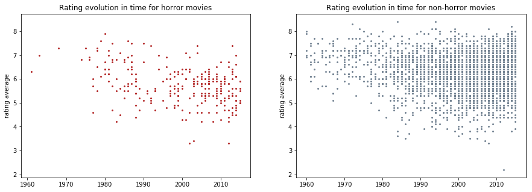

```python
# Create the figure and subplots; allign the axex

f_time = plt.figure(figsize=(15,5))
ax21 = f_time.add_subplot(121,title='Rating evolution in time for horror movies')
ax22 = f_time.add_subplot(122,title='Rating evolution in time for non-horror movies',sharey=ax21)

# add the charts to the plots
ax21.scatter(x=clean_df4[clean_df4['horror']==True]['release_year'], y=clean_df4[clean_df4['horror']==True]['vote_average'], color=['firebrick'],s=3.5)
ax22.scatter(x=clean_df4[clean_df4['horror']==False]['release_year'], y=clean_df4[clean_df4['horror']==False]['vote_average'], color=['slategrey'],s=3.5)

# add the necessary labels for the chart axes
ax21.set_ylabel('rating average')
ax22.set_ylabel('rating average')
```

> The 2 distributions seem fairy similar;
> - In both cases the years after 2000 meant an increase in the number of productions;
> - The range of ratings between 1960 and mid 90's seems to grow but more towards the lower numbers. After 2000, the yearly distributions seem to be more uniform.
> - Indeed as we saw from the numbers, the horror movies have a smaller range of ratings, and also there are centered around a slightly lower point.
> - Considering high ratings, the horror movies above 6.5-7 are rare, but for the other genres is quite considerable and the edge of the distribution is being pushed upwards constantly since 2000 (maybe also do to the higher volume of movies produced).

I can't help but wonder what movie is that 2.2 rating one. The other "stray" ratings seem similar between the horror and non-horrors. Let's extract it from the data:

```python
clean_df4[clean_df4['horror']==False][['release_year','original_title','vote_average']].sort_values(by='vote_average').head(1)
```

|  | release_year | original_title | vote_average |
| --- | --- | --- | --- |
| 4397 | 2012 | Foodfight! | 2.2 |

This is some sort of failed animation about fighting with food. I'll leave a link at the bottom for research. Moving on.

> Let's print out the financials: budget, revenue and profit.

```python
print('\n1. mean budget horror', h_bud_avg, ', mean budget non-horror', nh_bud_avg,\
     '\n mean budget  nonHorror/Horror ratio', round(nh_bud_avg/h_bud_avg,3),\
      '\n2. min budget horror', h_bud_min, ', min budget non-horror', nh_bud_min,\
     '\n min budget nonHorror/Horror ratio', round(nh_bud_min/h_bud_min,3),\
     '\n3. max budget horror', h_bud_max, ', max budget non-horror', nh_bud_max,\
     '\n max budget nonHorror/Horror ratio', round(nh_bud_max/h_bud_max,3))
```

```
1. mean budget horror 19.7284988889 , mean budget non-horror 46.5938394286
 mean budget  nonHorror/Horror ratio 2.362
2. min budget horror 0.0526 , min budget non-horror 0.0001
 min budget nonHorror/Horror ratio 0.002
3. max budget horror 184.7113 , max budget non-horror 425.0
 max budget nonHorror/Horror ratio 2.301
```

> - Interesting, so the pattern we saw in the ratings regarding the range is similar - very cheap and very expensive horrors are not as cheap or as expensive respectively as the other genres.
> - For the budget mean the story is different than for the ratings - on average the other genres receive more than twice the budget. So, the other genres are receiving on average twice the budget but they have only 8% better performance in terms of rating. Maybe budget and rating are not correlated - we'll see in a bit.
> - Also the top budget of other genres is more than twice as big as the horror movies.

Let's look at the revenues and profits also.

```python
print('\n1. mean revenue horror', h_rev_avg, ', mean revenue non-horror', nh_rev_avg,\
     '\n mean revenue  nonHorror/Horror ratio', round(nh_rev_avg/h_rev_avg,3),\
      '\n2. min revenue horror', h_rev_min, ', min revenue non-horror', nh_rev_min,\
     '\n min revenue nonHorror/Horror ratio', round(nh_rev_min/h_rev_min,3),\
     '\n3. max revenue horror', h_rev_max, ', max revenue non-horror', nh_rev_max,\
     '\n max revenue nonHorror/Horror ratio', round(nh_rev_max/h_rev_max,3))
```

```
1. mean revenue horror 78.2740722222 , mean revenue non-horror 142.428849457
 mean revenue  nonHorror/Horror ratio 1.82
2. min revenue horror 0.0029 , min revenue non-horror 0.0001
 min revenue nonHorror/Horror ratio 0.034
3. max revenue horror 1907.0058 , max revenue non-horror 2827.1238
 max revenue nonHorror/Horror ratio 1.482
```

```python
print('\n1. mean profit horror', h_pf_avg, ', mean profit non-horror', nh_pf_avg,\
     '\n mean profit  nonHorror/Horror ratio', round(nh_pf_avg/h_pf_avg,3),\
      '\n2. min profit horror', h_pf_min, ', min profit non-horror', nh_pf_min,\
     '\n min profit nonHorror/Horror ratio', round(nh_pf_min/h_pf_min,3),\
     '\n3. max profit horror', h_pf_max, ', max profit non-horror', nh_pf_max,\
     '\n max profit nonHorror/Horror ratio', round(nh_pf_max/h_pf_max,3))
```

```
1. mean profit horror 1101.73444444 , mean profit non-horror 357.38322
 mean profit  nonHorror/Horror ratio 0.324
2. min profit horror -99.9 , min profit non-horror -100.0
 min profit nonHorror/Horror ratio 1.001
3. max profit horror 42564.35 , max profit non-horror 69856.94
 max profit nonHorror/Horror ratio 1.641
```

... the plot thickens:

> - Both the average and max budget for other genres was 2.3 higher than for the horror movies and now we see that the revenues are just 1.8 times higher on average and 1.5 on the max level. Plainly said, on average other genres spend a lot more than they make more vs the horrors.
> - And, for the profit it appears on average the horror movies are 3 times more profitable that the other genres.

We need a bit more perspective as it seems the intuition *"you spend more money > you make better things and make more money"* doesn't seem to be working.

> - Let's check how budget and revenue are correlated :

```
Text(0,0.5,'Budget - M$')
```

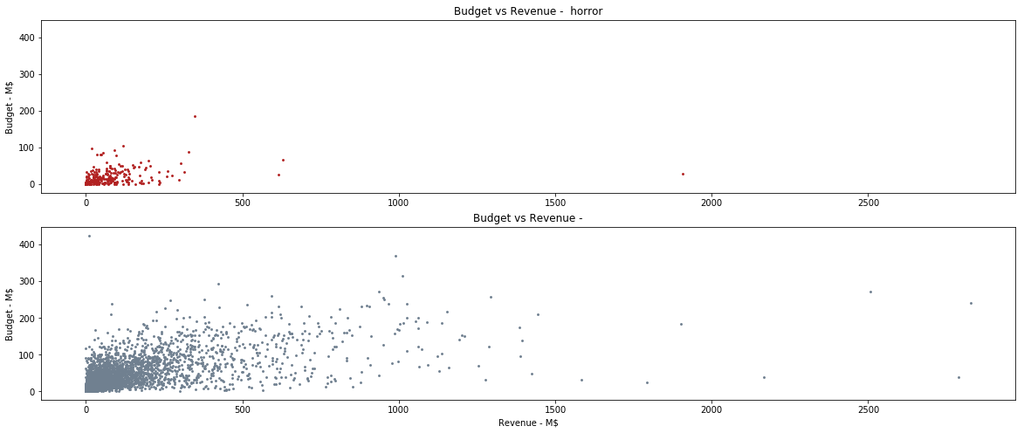

```python
# Create the figure and subplots; allign the axex
f_fin1 = plt.figure(figsize=(20,8))
ax41 = f_fin1.add_subplot(211,title='Budget vs Revenue -  horror')
ax42 = f_fin1.add_subplot(212,title='Budget vs Revenue -',sharey=ax41,sharex=ax41)

# add the charts to the plots
ax41.scatter(y=clean_df4[clean_df4['horror']==True]['budget_adj'], x=clean_df4[clean_df4['horror']==True]['revenue_adj'], color=['firebrick'],s=3.5)
ax42.scatter(y=clean_df4[clean_df4['horror']==False]['budget_adj'], x=clean_df4[clean_df4['horror']==False]['revenue_adj'], color=['slategrey'],s=3.5)

# add the necessary labels for the chart axes
ax42.set_xlabel('Revenue - M$')
ax41.set_ylabel('Budget - M$')
ax42.set_ylabel('Budget - M$')
```

So investing money does not seem to be correlated with higher earnings. Let's look at the ratings vs the financials. Intuitively, based on what we saw until now I would guess the ratings will not be correlated with the budget, but it will with the revenue.

```
Text(0.5,0,'Profit - %')
```

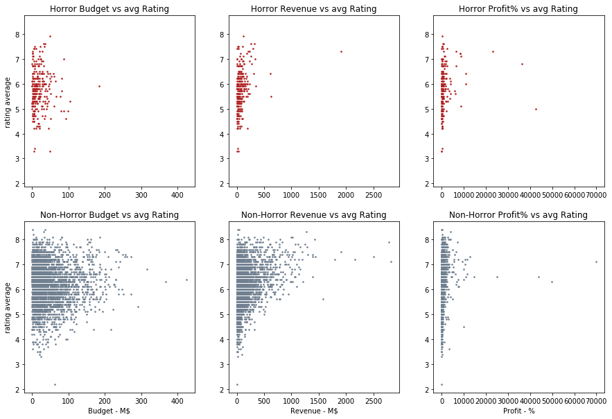

```python
# Create the figure and subplots; allign the axex
f_time2 = plt.figure(figsize=(15,10))
ax312 = f_time2.add_subplot(231,title='Horror Budget vs avg Rating')
ax322 = f_time2.add_subplot(232,title='Horror Revenue vs avg Rating',sharey=ax312)
ax332 = f_time2.add_subplot(233,title='Horror Profit% vs avg Rating',sharey=ax312)
ax342 = f_time2.add_subplot(234,title='Non-Horror Budget vs avg Rating',sharey=ax312,sharex=ax312)
ax352 = f_time2.add_subplot(235,title='Non-Horror Revenue vs avg Rating',sharey=ax312,sharex=ax322)
ax362 = f_time2.add_subplot(236,title='Non-Horror Profit% vs avg Rating',sharey=ax312,sharex=ax332)

# add the charts to the plots
ax312.scatter(x=clean_df4[clean_df4['horror']==True]['budget_adj'], y=clean_df4[clean_df4['horror']==True]['vote_average'], color=['firebrick'],s=2.5)
ax322.scatter(x=clean_df4[clean_df4['horror']==True]['revenue_adj'], y=clean_df4[clean_df4['horror']==True]['vote_average'], color=['firebrick'],s=2.5)
ax332.scatter(x=clean_df4[clean_df4['horror']==True]['profit_%'], y=clean_df4[clean_df4['horror']==True]['vote_average'], color=['firebrick'],s=2.5)
ax342.scatter(x=clean_df4[clean_df4['horror']==False]['budget_adj'], y=clean_df4[clean_df4['horror']==False]['vote_average'], color=['slategrey'],s=2.5)
ax352.scatter(x=clean_df4[clean_df4['horror']==False]['revenue_adj'], y=clean_df4[clean_df4['horror']==False]['vote_average'], color=['slategrey'],s=2.5)
ax362.scatter(x=clean_df4[clean_df4['horror']==False]['profit_%'], y=clean_df4[clean_df4['horror']==False]['vote_average'], color=['slategrey'],s=2.5)

# add the necessary labels for the chart axes
ax312.set_ylabel('rating average')
ax342.set_ylabel('rating average')
ax342.set_xlabel('Budget - M$')
ax352.set_xlabel('Revenue - M$')
ax362.set_xlabel('Profit - %')
```

> Let's look at them 2 by 2:
> - Budget vs Rating: if you are investing in a horror, it doesn't seem to make much difference in terms of rating if you spend more - most of the budgets over ~80M have generated ratings less than 6. However, the other genres appear to benefit from better funding - movies with more than 100M budget have more ratings higher than 6 than below.
> - Revenue vs Rating: For the horror, again the fact that a movie has a higer rating does not have much correlation with the revenue. The few movies with rating over 6.5 perform more or less like the ones around 6 - with one exception: Jaws - see below. Again for the other genres, big money is gained by movies with a better rating.
> - Profit vs Rating- the revenue and profit distributions are similar.

Two things cross my mind as I look at all charts:

> 1. There are many highly rated movies that have very small budgets, revenues and profits. But low rated movies, although they might spend some considerable budget, they don't bring high revenue or profit.
> 2. Most of the money are both spent and cashed in by the average rated movies.

```python
clean_df4[clean_df4['horror']==True][['revenue_adj','original_title','release_year']].sort_values(by='revenue_adj',ascending=False).head(1)
```

|  | revenue_adj | original_title | release_year |
| --- | --- | --- | --- |
| 8983 | 1907.0058 | Jaws | 1975 |

> Talking about outliers, let's do some justice and look at the 5 names we removed earlier:

```python
#print the outliers with huge profits we removed earlier.
clean_df3.query('budget_adj>0 & revenue_adj>0')[['id','original_title','release_year',\
'cast','budget_adj','revenue_adj','profit_%']].sort_values(by='profit_%',ascending=False).head(5)
```

|  | id | original_title | release_year | cast | budget_adj | revenue_adj | profit_% |
| --- | --- | --- | --- | --- | --- | --- | --- |
| 9634 | 8856 | The Karate Kid, Part II | 1986 | Ralph Macchio\|Pat Morita\|Martin Kove\|Charlie T... | 0.0002 | 228.9886 | 1.144942e+08 |
| 5581 | 11338 | Into the Night | 1985 | Jeff Goldblum\|Michelle Pfeiffer\|Stacey Pickren... | 0.0002 | 13.5820 | 6.790900e+06 |
| 3258 | 50217 | From Prada to Nada | 2011 | Camilla Belle\|Alexa PenaVega\|April Bowlby\|Wilm... | 0.0001 | 2.4235 | 2.423400e+06 |
| 6757 | 23827 | Paranormal Activity | 2007 | Katie Featherston\|Micah Sloat\|Mark Fredrichs\|A... | 0.0158 | 203.3462 | 1.286901e+06 |
| 2187 | 2667 | The Blair Witch Project | 1999 | Heather Donahue\|Michael C. Williams\|Joshua Leo... | 0.0327 | 324.6451 | 9.926985e+05 |

> - **The Karate Kid, Part II** - according to the wikipedia (although without a source cited) the budget was arround 13M, not 200 dolars.
> - **Into the Night** - on IMDB they share an estimation of arround 8M.
> - **From Prada to Nada** - I could not find any info, but it's a movie from 2011. They must have at least payed the guy that did the poster - 100 dolars could not help much.
> - **Paranormal Activity** - they really spent just 15k and made millions.
> - **The Blair Witch Project** - wikipedia says the cost was between 200k and 500k.

> > The karate kid II: https://en.wikipedia.org/wiki/The_Karate_Kid_(franchise)  
> > Into the night: https://www.google.com/url?sa=t&rct=j&q=&esrc=s&source=web&cd=&cad=rja&uact=8&ved=2ahUKEwiBl8He3qzsAhXBMewKHU9HDgYQFjACegQIBRAC&url=https%3A%2F%2Fwww.imdb.com%2Ftitle%2Ftt0089346%2F&usg=AOvVaw25XKBHExm3y5J1ensxrw1x  
> > Paranormal Activity : https://en.wikipedia.org/wiki/Paranormal_Activity  
> > The Blair Witch Project: https://en.wikipedia.org/wiki/The_Blair_Witch_Project

### 2. Are any horror sub-genres better that others?

Let's breakdown the horror dataset into subgenres and see plot their numbers.

```python
# create locations and x labels
locations2=[1,2,3,4,5]
labels2=['Zombies','Vampires','Devils&Ghosts','Psychos','Others']
```

```python
#compute total number of movies per sub-genre and join them in an array
z_count = clean_df4h[clean_df4h['horror']==True]['zombies'].sum()
v_count= clean_df4h[clean_df4h['horror']==True]['vampires'].sum()
d_count= clean_df4h[clean_df4h['horror']==True]['devil_ghost'].sum()
p_count= clean_df4h[clean_df4h['horror']==True]['psycho'].sum()
o_count= clean_df4h[clean_df4h['horror']==True]['other'].sum()
counts=[z_count,v_count,d_count,p_count,o_count]
```

```python
#compute average ratings per sub-genre and join them in an array
z_score = clean_df4h[clean_df4h['zombies']==True]['vote_average'].mean()
v_score= clean_df4h[clean_df4h['vampires']==True]['vote_average'].mean()
d_score= clean_df4h[clean_df4h['devil_ghost']==True]['vote_average'].mean()
p_score= clean_df4h[clean_df4h['psycho']==True]['vote_average'].mean()
o_score= clean_df4h[clean_df4h['other']==True]['vote_average'].mean()
scores=[z_score,v_score,d_score,p_score,o_score]
```

```python
#compute average revenues per sub-genre and join them in an array
z_revenue = clean_df4h[clean_df4h['zombies']==True]['revenue_adj'].mean()
v_revenue= clean_df4h[clean_df4h['vampires']==True]['revenue_adj'].mean()
d_revenue= clean_df4h[clean_df4h['devil_ghost']==True]['revenue_adj'].mean()
p_revenue= clean_df4h[clean_df4h['psycho']==True]['revenue_adj'].mean()
o_revenue= clean_df4h[clean_df4h['other']==True]['revenue_adj'].mean()
revenues=[z_revenue,v_revenue,d_revenue,p_revenue,o_revenue]
```

```python
#compute average profits per sub-genre and join them in an array
z_profit = clean_df4h[clean_df4h['zombies']==True]['profit_%'].mean()
v_profit= clean_df4h[clean_df4h['vampires']==True]['profit_%'].mean()
d_profit= clean_df4h[clean_df4h['devil_ghost']==True]['profit_%'].mean()
p_profit= clean_df4h[clean_df4h['psycho']==True]['profit_%'].mean()
o_profit= clean_df4h[clean_df4h['other']==True]['profit_%'].mean()
profits=[z_profit,v_profit,d_profit,p_profit,o_profit]
```

```
Text(0,0.5,'Profit - %')
```

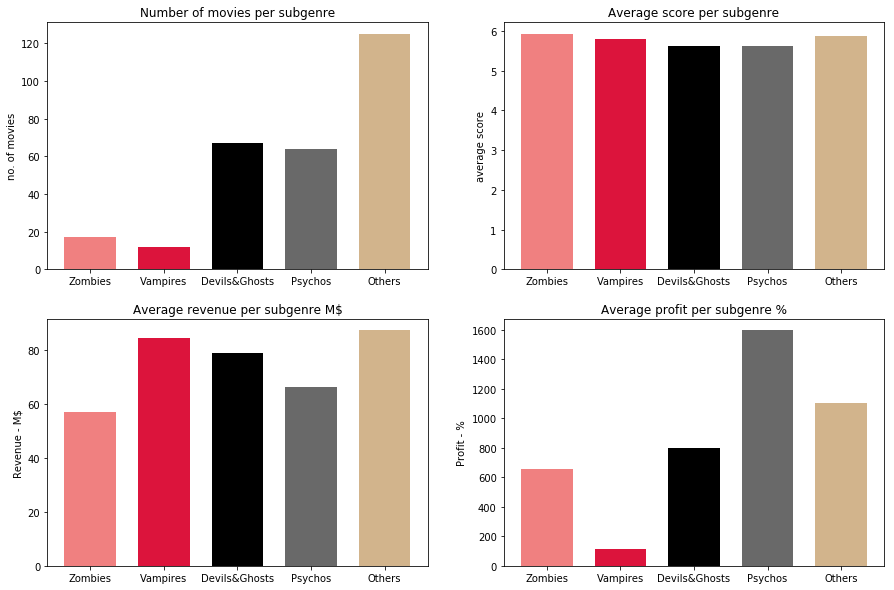

```python
# Create the figure and subplots; allign the axex
f_sg = plt.figure(figsize=(15,10))
ax1 = f_sg.add_subplot(221,title='Number of movies per subgenre')
ax2 = f_sg.add_subplot(222,title='Average score per subgenre')
ax3 = f_sg.add_subplot(223,title='Average revenue per subgenre M$')
ax4 = f_sg.add_subplot(224,title='Average profit per subgenre %')

# add the charts to the plots
ax1.bar(locations2, counts, tick_label=labels2, width=0.7, color=['lightcoral','crimson','black','dimgrey','tan'])
ax2.bar(locations2, scores, tick_label=labels2, width=0.7, color=['lightcoral','crimson','black','dimgrey','tan'])
ax3.bar(locations2, revenues, tick_label=labels2, width=0.7, color=['lightcoral','crimson','black','dimgrey','tan'])
ax4.bar(locations2, profits, tick_label=labels2, width=0.7, color=['lightcoral','crimson','black','dimgrey','tan'])

# add the necessary labels for the chart axes
ax1.set_ylabel('no. of movies')
ax2.set_ylabel('average score')
ax3.set_ylabel('Revenue - M$')
ax4.set_ylabel('Profit - %')
```

So apparently, from the genres we identified, the most numerous are the ones with devils (+ ghosts, demons, possesions, etc.) and the ones with psycho-killers.

In terms of average rating there is not much difference, but zombies seem to have a bit of an edge.

### 3. Are big names in the industry (actors and directors) sharing their talents with the horror genre?

> - First we'll need to compute some averages for the star actor/director measures so we can plot them as bar charts.

```python
#set locations
locations1=[1,2]
#set x labels
labels1=['Horror','Non-horror']

#compute average star actor measures and join them in an array
act_star_h = clean_df4[clean_df4['horror']==True]['star_act'].mean()
act_star_nh= clean_df4[clean_df4['horror']==False]['star_act'].mean()

act_stars=[act_star_h,act_star_nh]

#compute average star director measures and join them in an array
dir_star_h = clean_df4[clean_df4['horror']==True]['star_dir'].mean()
dir_star_nh= clean_df4[clean_df4['horror']==False]['star_dir'].mean()

dir_stars=[dir_star_h,dir_star_nh]
print(act_stars,dir_stars)
```

```
[0.055555555555555552, 0.18828571428571428] [0.055555555555555552, 0.158]
```

> - And now we create a dashboard.

```
Text(0,0.5,'number of movies')
```

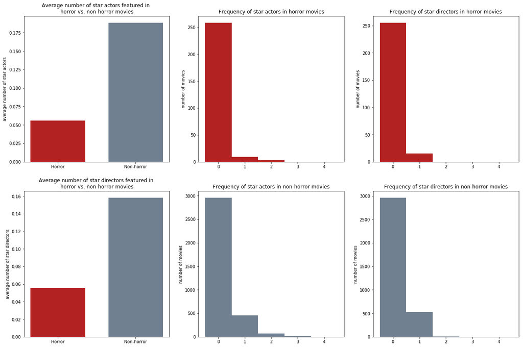

```python
# Create the figure and subplots; allign the axex
f_star = plt.figure(figsize=(21,14))
ax71 = f_star.add_subplot(231,title='Average number of star actors featured in \nhorror vs. non-horror movies')
ax74 = f_star.add_subplot(234,title='Average number of star directors featured in \nhorror vs. non-horror movies')
ax75 = f_star.add_subplot(235,title='Frequency of star actors in non-horror movies')
ax76 = f_star.add_subplot(236,title='Frequency of star directors in non-horror movies')
ax72 = f_star.add_subplot(232,title='Frequency of star actors in horror movies',sharex=ax75)
ax73 = f_star.add_subplot(233,title='Frequency of star directors in horror movies',sharex=ax76)

# add the charts to the plots
ax71.bar(locations1, act_stars, tick_label=labels1, width=0.7, color=['firebrick','slategrey'])
ax74.bar(locations1, dir_stars, tick_label=labels1, width=0.7, color=['firebrick','slategrey'])
ax72.hist(clean_df4[clean_df4['horror']==True]['star_act'], color=['firebrick'], bins=[-0.5,0.5,1.5,2.5,3.5,4.5], align='mid')
ax75.hist(clean_df4[clean_df4['horror']==False]['star_act'], color=['slategrey'], bins=[-0.5,0.5,1.5,2.5,3.5,4.5], align='mid')
ax73.hist(clean_df4[clean_df4['horror']==True]['star_dir'], color=['firebrick'],bins=[-0.5,0.5,1.5,2.5,3.5,4.5], align='mid')
ax76.hist(clean_df4[clean_df4['horror']==False]['star_dir'], color=['slategrey'],bins=[-0.5,0.5,1.5,2.5,3.5,4.5], align='mid')

# add the necessary labels for the chart axes
ax71.set_ylabel('average number of star actors')
ax74.set_ylabel('average number of star directors')
ax72.set_ylabel('number of movies')
ax73.set_ylabel('number of movies')
ax75.set_ylabel('number of movies')
ax76.set_ylabel('number of movies')
```

The "density" of stars, both actors and directors, for the horror movies is 3 times less than for the rest of the movies. So the starts have a disprefference for the horror movies.  
In terms of how many movies feature stars, most of them have none, be it horror or non-horror. However, when we look at the height of the bars for 1 or more stars vs the bar of 0 stars, the proportion of at least 1 star in the non-horror movies is a lot bigger than in the horror movies. This goes for both actors and directors.

**Here you'll find some links I used for documentation:**  
Quora discussion regarding the length of the average movie: - they have some nice charts and stats:  
https://www.quora.com/How-long-is-the-average-movie

Details about the movie Me, Earl and the dying girl - because it actually had revenue, not 0 as in the data set.  
https://www.google.com/url?sa=t&rct=j&q=&esrc=s&source=web&cd=&cad=rja&uact=8&ved=2ahUKEwirjr7W_KzsAhVCjqQKHZKEAQ0QFjABegQIBBAC&url=https%3A%2F%2Fwww.imdb.com%2Ftitle%2Ftt2582496%2F&usg=AOvVaw3_vUw89Ym65oLGZQ87b3Ff

Details about the failure of the movie FoodFight.  
https://www.nytimes.com/2013/08/11/movies/the-rise-and-fall-of-the-computer-animated-foodfight.html

## Conclusions

First let me point out some caveats:

> - Since I decided to remove all records of the dataset with 0 revenue and budget, it is possible that the results I got are far from the real world view. Take into account that the purpose was to analyze the current dataset so no inference should be made based on it.
> - The analysis of star directors and actors preference for some genres is mainly an exercise into data manipulation and at most a very accurate portrayal of my personal views on what makes a star.
> - Although I noticed some patterns in the data, the analysis does not suggest that the findings have any relevance in the real world.
> - The data distributions look pretty neat so there might be some non-linear correlation that I still need to learn about.

What I have found:

> - Horror movies have an average rating only a little lower than the other movies (8% lower), but also they have less top rates.
> - Horror movies receive, on average, half the budget vs what other movies receive and they also bring half the revenues.
> - There's no linear correlation between the amount invested in a movie and the revenue it brings, no matter the genre.
> - The higher rating for the horror movies is not linearly correlated with higher earnings, but for the other genres there is a hint that better rating will bring some money. On the other hand, if the rating is low, there's very little chance that movie will get good revenues.
> - The biggest spenders and earners are actually the average rated movies.
> - The most common themes in horror movies are devil/demons/ghosts and psycho killers - and the psychos actually bring the best profits.
> - The stars (as defined by me) are found more often in other genres than in horrors.

In summary, I would say horror movies are actually not as bad as I imagined; a few actually have made remarkable revenues and received very good ratings. In the future I would like to see more "stars" in the credit lines of horror movies.

## Submitting your Project

> Before you submit your project, you need to create a .html or .pdf version of this notebook in the workspace here. To do that, run the code cell below. If it worked correctly, you should get a return code of 0, and you should see the generated .html file in the workspace directory (click on the orange Jupyter icon in the upper left).

> Alternatively, you can download this report as .html via the **File** > **Download as** submenu, and then manually upload it into the workspace directory by clicking on the orange Jupyter icon in the upper left, then using the Upload button.

> Once you've done this, you can submit your project by clicking on the "Submit Project" button in the lower right here. This will create and submit a zip file with this .ipynb doc and the .html or .pdf version you created. Congratulations!

```python
#from subprocess import call
#call(['python', '-m', 'nbconvert', 'Investigate_a_Dataset.ipynb'])
```